# Biostat 212a Homework 4

Due Mar. 5, 2024 @ 11:59PM

Author

Yilin He, UID: 905789961

Published

March 14, 2024

## 1 ISL Exercise 8.4.3 (10pts)

3. Consider the Gini index, classification error, and entropy in a simple classification setting with two classes. Create a single plot that dis- plays each of these quantities as a function of $\hat p_{m1}$. The x-axis should display $\hat p_{m1}$, ranging from 0 to 1, and the y-axis should display the value of the Gini index, classification error, and entropy.

Hint: In a setting with two classes, $\hat p_{m1}$ = 1 − $\hat p_{m2}$. You could make this plot by hand, but it will be much easier to make in R

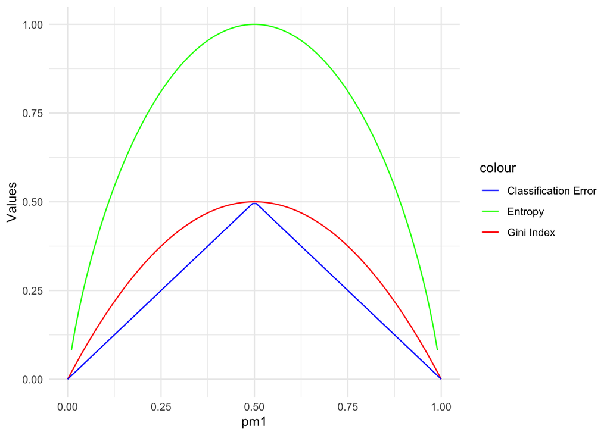

```r
library(ggplot2)

pm1 <- seq(0,1,length.out = 100)
gini <- 2 * pm1 * (1 - pm1)
class_error <- 1 - pmax(pm1, 1 - pm1)
entropy <- -pm1 * log2(pm1) - (1 - pm1) * log2(1 - pm1)

df <- data.frame(pm1, gini, class_error, entropy)

ggplot (df, aes(x=pm1)) +
  geom_line(aes(y=gini, color="Gini Index")) +
  geom_line(aes(y=class_error, color="Classification Error")) +
  geom_line(aes(y=entropy, color="Entropy")) +
  labs(x= "pm1", y="Values") +
  scale_color_manual(values=c("Gini Index"="red",
                              "Classification Error"="blue",
                              "Entropy"="green")) +
  theme_minimal()
```

## 2 ISL Exercise 8.4.4 (10pts)

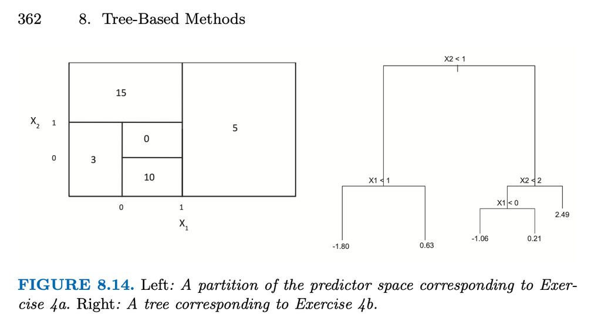

4. This question relates to the plots in Figure 8.14.

1. Sketch the tree corresponding to the partition of the predictor space illustrated in the left-hand panel of Figure 8.14. The numbers inside the boxes indicate the mean of Y within each region.

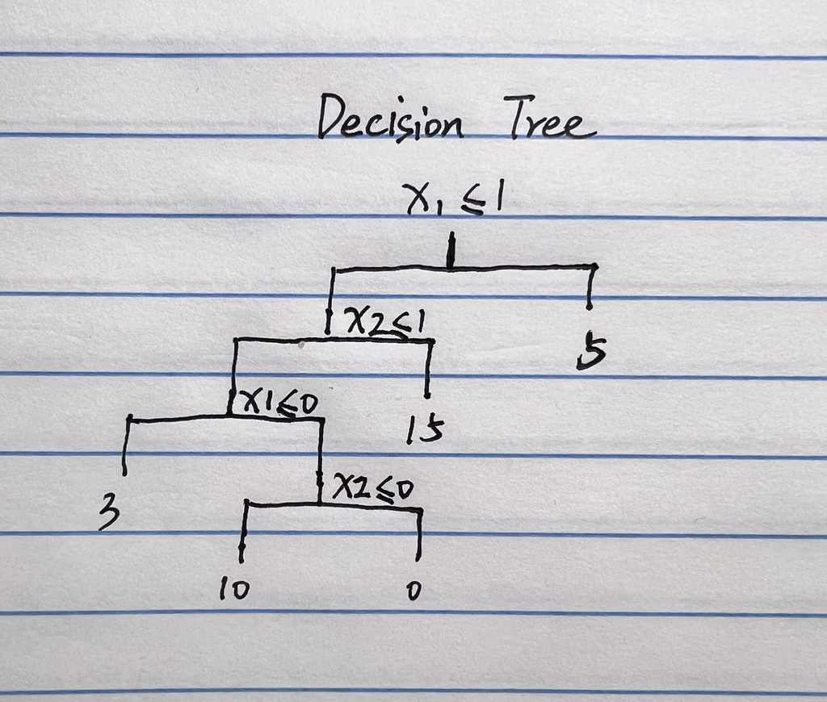

2. Create a diagram similar to the left-hand panel of Figure 8.14, using the tree illustrated in the right-hand panel of the same figure. You should divide up the predictor space into the correct regions, and indicate the mean for each region.

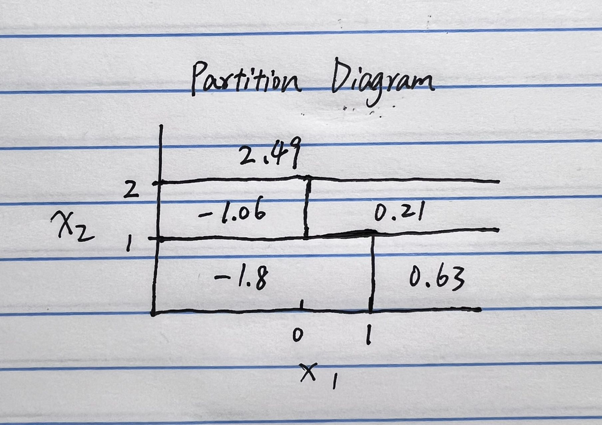

## 3 ISL Exercise 8.4.5 (10pts)

5. Suppose we produce ten bootstrapped samples from a data set containing red and green classes. We then apply a classification tree to each bootstrapped sample and, for a specific value of X, produce 10 estimates of P(Class is Red X): 0.1,0.15,0.2,0.2,0.55,0.6,0.6,0.65,0.7, and 0.75.

There are two common ways to combine these results together into a single class prediction. One is the majority vote approach discussed in this chapter. The second approach is to classify based on the average probability. In this example, what is the final classification under each of these two approaches?

**Answer:**

```r
prob <- c(0.1,0.15,0.2,0.2,0.55,0.6,0.6,0.65,0.7,0.75)

Major <- max(ifelse(prob > 0.5, "Red", "Green"))
cat("Majority vote classification is:", Major, "\n")
```

```
Majority vote classification is: Red
```

```r
Ave_prob_class <- ifelse(mean(prob) > 0.5, "Red", "Green")
cat("Average probability classification is:", Ave_prob_class, "\n")
```

```
Average probability classification is: Green
```

```r
Ave_prob <- mean(prob)
cat("Average probability is:", Ave_prob, "\n")
```

```
Average probability is: 0.45
```

## 4 ISL Lab 8.3. `Boston` data set (30pts)

Follow the machine learning workflow to train random forest and boosting methods for predicting `medv`. Evaluate out-of-sample performance on a test set.

```r
# 1 Overview
Boston %>% tbl_summary()
```

| **Characteristic** | **N = 506**<sup>1</sup> |
| --- | --- |
| crim | 0.3 (0.1, 3.7) |
| zn | 0 (0, 13) |
| indus | 9.7 (5.2, 18.1) |
| chas | 35 (6.9%) |
| nox | 0.54 (0.45, 0.62) |
| rm | 6.21 (5.89, 6.62) |
| age | 78 (45, 94) |
| dis | 3.21 (2.10, 5.19) |
| rad |  |
| 1 | 20 (4.0%) |
| 2 | 24 (4.7%) |
| 3 | 38 (7.5%) |
| 4 | 110 (22%) |
| 5 | 115 (23%) |
| 6 | 26 (5.1%) |
| 7 | 17 (3.4%) |
| 8 | 24 (4.7%) |
| 24 | 132 (26%) |
| tax | 330 (279, 666) |
| ptratio | 19.05 (17.40, 20.20) |
| lstat | 11 (7, 17) |
| medv | 21 (17, 25) |

<sup>1</sup> Median (IQR); n (%)

### 4.1 Random forests for Prediction

```
# A tibble: 30 × 8
    mtry trees .metric .estimator  mean     n std_err .config
   <int> <int> <chr>   <chr>      <dbl> <int>   <dbl> <chr>
 1     1   100 rmse    standard   4.67      5  0.565  Preprocessor1_Model01
 2     1   100 rsq     standard   0.742     5  0.0739 Preprocessor1_Model01
 3     1   300 rmse    standard   4.63      5  0.630  Preprocessor1_Model02
 4     1   300 rsq     standard   0.744     5  0.0804 Preprocessor1_Model02
 5     1   500 rmse    standard   4.66      5  0.606  Preprocessor1_Model03
 6     1   500 rsq     standard   0.745     5  0.0768 Preprocessor1_Model03
 7     2   100 rmse    standard   3.95      5  0.584  Preprocessor1_Model04
 8     2   100 rsq     standard   0.805     5  0.0608 Preprocessor1_Model04
 9     2   300 rmse    standard   3.88      5  0.604  Preprocessor1_Model05
10     2   300 rsq     standard   0.806     5  0.0652 Preprocessor1_Model05
# ℹ 20 more rows
```

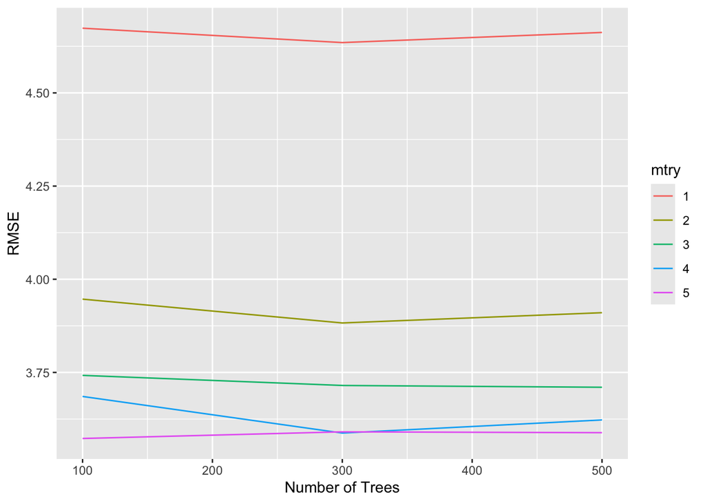

```r
# 3 Initial split into test and non-test sets
set.seed(101)
boston_split <- initial_split(Boston, prop = 0.5)

boston_other <- training(boston_split)
boston_test <- testing(boston_split)

# 4 recipe (R)
boston_recipe <- recipe(medv ~ ., data = boston_other) %>%
  step_naomit(medv) %>%
  step_zv(all_numeric_predictors())

# 5 Model
boston_mod <-
  rand_forest(
    mode = "regression",
    mtry = tune(),
    trees = tune()
  ) %>%
  set_engine("ranger")

# 6 workflow (R)
boston_wf <- workflow() %>%
  add_recipe(boston_recipe) %>%
  add_model(boston_mod)

# 7 Tuning grid
boston_grid <- grid_regular(
    trees(range = c(100L, 500L)),
    mtry(range = c(1L, 5L)),
    levels = c(3,5)
  )

# 8 Cross-validation (CV)
## Set cross-validation partitions
set.seed(101)
folds <- vfold_cv(boston_other, v = 5)

## Fit cross-validation
boston_fit <- boston_wf %>%
  tune_grid(resamples = folds,
            grid = boston_grid,
            metrics = metric_set(rmse, rsq))

## visualize CV results
boston_fit %>%
  collect_metrics() %>%
  print(width = Inf) %>%
  filter(.metric == "rmse") %>%
  mutate(mtry = as.factor(mtry)) %>%
  ggplot(aes(x = trees, y = mean, color = mtry)) +
  geom_line() +
  labs(x = "Number of Trees", y = "RMSE")
```

The line for ‘mtry’ equal to 1 shows the highest RMSE, indicating less predictive accuracy, while ‘mtry’ values of 4 and 5 give the lowest RMSE, indicating a more accurate model. However, there is little change in RMSE after a certain number of trees, suggesting that adding more trees beyond this point doesn’t significantly improve the model.

```r
## Show the top 5 models
boston_fit %>%
  show_best("rmse")
```

```
# A tibble: 5 × 8
   mtry trees .metric .estimator  mean     n std_err .config
  <int> <int> <chr>   <chr>      <dbl> <int>   <dbl> <chr>
1     5   100 rmse    standard    3.57     5   0.584 Preprocessor1_Model13
2     4   300 rmse    standard    3.59     5   0.577 Preprocessor1_Model11
3     5   500 rmse    standard    3.59     5   0.576 Preprocessor1_Model15
4     5   300 rmse    standard    3.59     5   0.602 Preprocessor1_Model14
5     4   500 rmse    standard    3.62     5   0.581 Preprocessor1_Model12
```

```r
# let's select the best model
best_rf <- boston_fit %>%
  select_best("rmse")
best_rf
```

```
# A tibble: 1 × 3
   mtry trees .config
  <int> <int> <chr>
1     5   100 Preprocessor1_Model13
```

```r
# 9 Finalize the model
## Final workflow
final_wf <-
  boston_wf %>%
  finalize_workflow(best_rf)

## Fit the whole training set, then predict
final_fit <-
  final_wf %>%
  last_fit(boston_split)

## Test Metrics
final_fit %>%
  collect_metrics()
```

```
# A tibble: 2 × 4
  .metric .estimator .estimate .config
  <chr>   <chr>          <dbl> <chr>
1 rmse    standard       3.68  Preprocessor1_Model1
2 rsq     standard       0.861 Preprocessor1_Model1
```

### 4.2 Boosting For Prediction

```
# A tibble: 80 × 8
   tree_depth learn_rate .metric .estimator   mean     n std_err
        <int>      <dbl> <chr>   <chr>       <dbl> <int>   <dbl>
 1          1    0.001   rmse    standard   10.3       5  0.537
 2          1    0.001   rsq     standard    0.663     5  0.0481
 3          2    0.001   rmse    standard    9.89      5  0.512
 4          2    0.001   rsq     standard    0.722     5  0.0568
 5          3    0.001   rmse    standard    9.83      5  0.523
 6          3    0.001   rsq     standard    0.736     5  0.0564
 7          4    0.001   rmse    standard    9.80      5  0.520
 8          4    0.001   rsq     standard    0.747     5  0.0608
 9          1    0.00190 rmse    standard    6.28      5  0.448
10          1    0.00190 rsq     standard    0.726     5  0.0429
   .config
   <chr>
 1 Preprocessor1_Model01
 2 Preprocessor1_Model01
 3 Preprocessor1_Model02
 4 Preprocessor1_Model02
 5 Preprocessor1_Model03
 6 Preprocessor1_Model03
 7 Preprocessor1_Model04
 8 Preprocessor1_Model04
 9 Preprocessor1_Model05
10 Preprocessor1_Model05
# ℹ 70 more rows
```

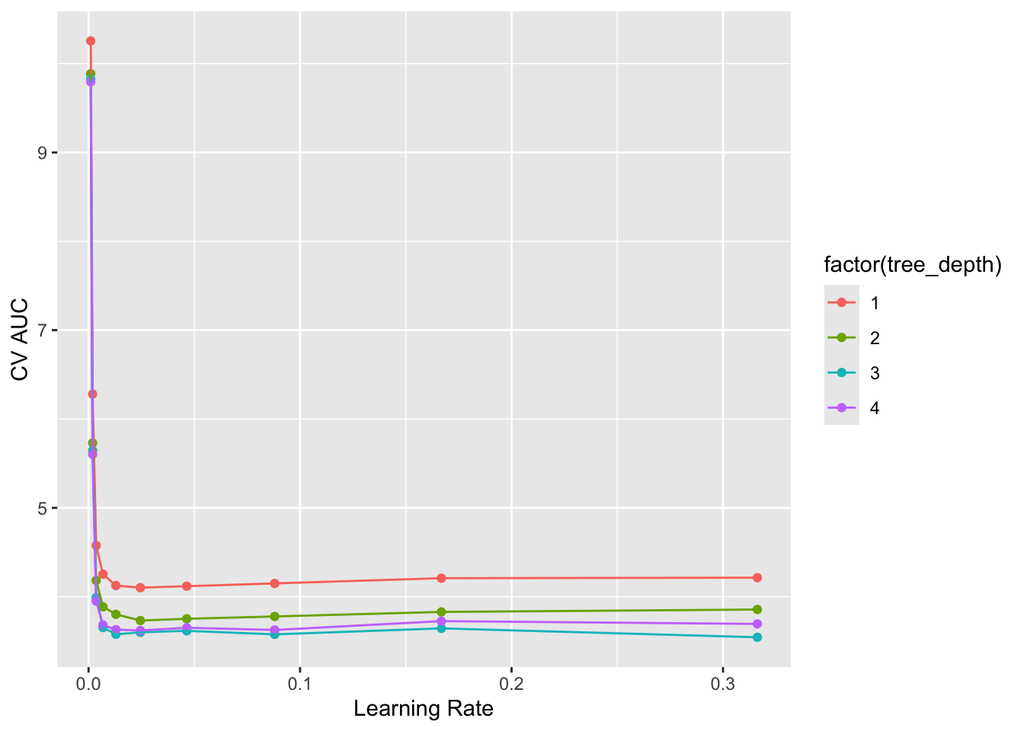

```r
# 3 Initial split into test and non-test sets
set.seed(101)

boston_split <- initial_split(Boston,
                              prop = 0.5)

boston_other <- training(boston_split)
boston_test <- testing(boston_split)

# 4 recipe (R)
gb_recipe <-
  recipe(
    medv ~ .,
    data = boston_other
  ) %>%
  step_naomit(medv) %>%
  step_zv(all_numeric_predictors())

# 5 Model
gb_mod <-
  boost_tree(
    mode = "regression",
    trees = 1000,
    tree_depth = tune(),
    learn_rate = tune()
  ) %>%
  set_engine("xgboost")

# 6 workflow (R)
gb_workflow <- workflow() %>%
  add_recipe(gb_recipe) %>%
  add_model(gb_mod)

# 7 Tuning grid
gb_grid <- grid_regular(
    tree_depth(range = c(1L, 4L)),
    learn_rate(range = c(-3, -0.5),
               trans = log10_trans()),
    levels = c(4, 10)
  )

# 8 Cross-validation (CV)
## Set cross-validation partitions
set.seed(101)
folds <- vfold_cv(boston_other, v = 5)

## Fit cross-validation
gb_fit <- gb_workflow %>%
  tune_grid(
    resamples = folds,
    grid = gb_grid,
    metrics = metric_set(rmse, rsq)
  )

## Visualize CV results
gb_fit %>%
  collect_metrics() %>%
  print(width = Inf) %>%
  filter(.metric == "rmse") %>%
  ggplot(mapping = aes(x = learn_rate, y = mean,
                       color = factor(tree_depth))) +
  geom_point() +
  geom_line() +
  labs(x = "Learning Rate", y = "CV AUC")
```

```r
## Show the top 5 models
gb_fit %>%
  show_best("rmse")
```

```
# A tibble: 5 × 8
  tree_depth learn_rate .metric .estimator  mean     n std_err .config
       <int>      <dbl> <chr>   <chr>      <dbl> <int>   <dbl> <chr>
1          3     0.316  rmse    standard    3.54     5   0.525 Preprocessor1_Mo…
2          3     0.0880 rmse    standard    3.58     5   0.519 Preprocessor1_Mo…
3          3     0.0129 rmse    standard    3.58     5   0.508 Preprocessor1_Mo…
4          3     0.0245 rmse    standard    3.60     5   0.518 Preprocessor1_Mo…
5          3     0.0464 rmse    standard    3.62     5   0.547 Preprocessor1_Mo…
```

```r
## Select the best model
best_gb <- gb_fit %>%
  select_best("rmse")
best_gb
```

```
# A tibble: 1 × 3
  tree_depth learn_rate .config
       <int>      <dbl> <chr>
1          3      0.316 Preprocessor1_Model39
```

```r
# 9 Finalize the model
## Final workflow
final_wf <-
  gb_workflow %>%
  finalize_workflow(
    best_gb
  )

## Fit the whole training set, then predict
final_fit <-
  final_wf %>%
  last_fit(
    boston_split
  )

## Test Metrics
final_fit %>%
  collect_metrics()
```

```
# A tibble: 2 × 4
  .metric .estimator .estimate .config
  <chr>   <chr>          <dbl> <chr>
1 rmse    standard       3.72  Preprocessor1_Model1
2 rsq     standard       0.850 Preprocessor1_Model1
```

The model has an $R^2$ value of 0.85, which indicates a strong fit to the data, explaining about 85% of the variation in the medv variable. However, the RMSE of 3.72 suggests that the model’s predictions are, on average, 3.72 units away from the actual values. Although the high $R^2$ suggests that the model explains a large proportion of the variability, there is still a risk of overfitting to the training data.

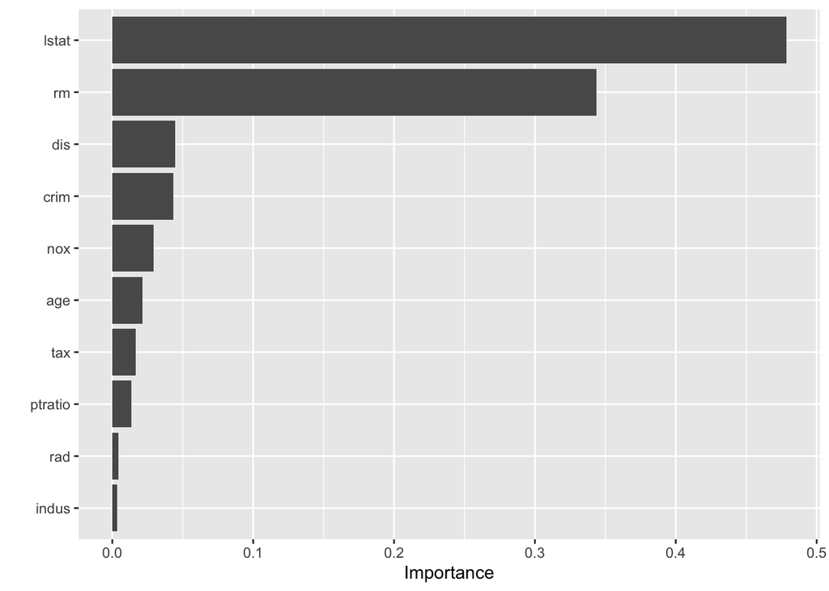

```r
# 10 Visualize the model
library(vip)

final_tree <- extract_workflow(final_fit)
final_tree %>%
  extract_fit_parsnip() %>%
  vip()
```

This bar graph shows the significance of different predictors in a model. The variable `lstat`, which measures the percentage of lower socio-economic status, is the most significant predictor, with the largest bar and the most substantial effect on the model’s predictions. The second most important predictor is the `rm` variable, which indicates the average number of rooms per dwelling. The model is influenced by variables such as `dis`, `crim`, `nox`, and `age`, albeit to a lesser extent. Variables like `tax`, `ptratio`, `rad`, and `indus` have a relatively lower impact on the model’s output.

## 5 ISL Lab 8.3 `Carseats` data set (30pts)

Follow the machine learning workflow to train random forest and boosting methods for classifying `Sales <= 8` versus `Sales > 8`. Evaluate out-of-sample performance on a test set.

### 5.1 Random Forest for Classification

```
# A tibble: 30 × 8
    mtry trees .metric  .estimator  mean     n std_err .config
   <int> <int> <chr>    <chr>      <dbl> <int>   <dbl> <chr>
 1     1   100 accuracy binary     0.775     5  0.0270 Preprocessor1_Model01
 2     1   100 roc_auc  binary     0.860     5  0.0149 Preprocessor1_Model01
 3     1   200 accuracy binary     0.765     5  0.0223 Preprocessor1_Model02
 4     1   200 roc_auc  binary     0.857     5  0.0169 Preprocessor1_Model02
 5     1   300 accuracy binary     0.771     5  0.0266 Preprocessor1_Model03
 6     1   300 roc_auc  binary     0.868     5  0.0135 Preprocessor1_Model03
 7     2   100 accuracy binary     0.778     5  0.0190 Preprocessor1_Model04
 8     2   100 roc_auc  binary     0.878     5  0.0164 Preprocessor1_Model04
 9     2   200 accuracy binary     0.787     5  0.0232 Preprocessor1_Model05
10     2   200 roc_auc  binary     0.886     5  0.0112 Preprocessor1_Model05
# ℹ 20 more rows
```

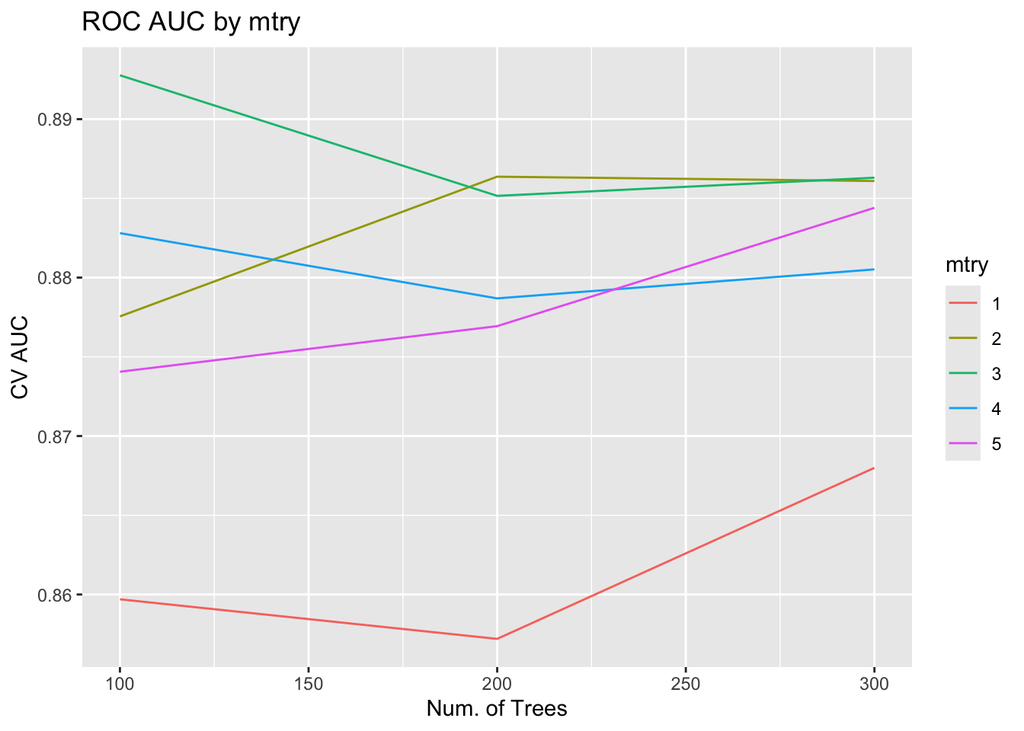

```r
# 2 Heart data
carseats <- Carseats %>%
  mutate(Sales = ifelse(Sales > 8, "high", "low"))

# 3 Initial split into test and non-test sets
set.seed(101)
carseats_split <- initial_split(carseats,
                              prop = 0.8,
                              strata = "Sales")

carseats_other <- training(carseats_split)
carseats_test <- testing(carseats_split)

# 4 recipe (R)
carseats_recipe <- recipe(Sales ~ ., data = carseats_other) %>%
  step_zv(all_numeric_predictors())

# 5 Model
carseats_mod <-
  rand_forest(
    mode = "classification",
    mtry = tune(),
    trees = tune()
  ) %>%
  set_engine("ranger")

# 6 workflow (R)
carseats_workflow <- workflow() %>%
  add_recipe(carseats_recipe) %>%
  add_model(carseats_mod)

# 7 Tuning grid
carseats_grid <- grid_regular(
    trees(range = c(100L, 300L)),
    mtry(range = c(1L, 5L)),
    levels = c(3,5))

# 8 Cross-validation (CV)
## Set cross-validation partitions
set.seed(101)
folds <- vfold_cv(carseats_other, v = 5)

## Fit cross-validation
carseats_fit <-
  carseats_workflow %>%
  tune_grid(
    resamples = folds,
    grid = carseats_grid,
    metrics = metric_set(roc_auc, accuracy)
  )

## Visualize CV results
carseats_fit %>%
  collect_metrics() %>%
  print(width = Inf) %>%
  filter(.metric == "roc_auc") %>%
  mutate(mtry = as.factor(mtry)) %>%
  ggplot(aes(x = trees, y = mean, color = mtry)) +
  geom_line() +
  labs(title = "ROC AUC by mtry",
       x = "Num. of Trees",
       y = "CV AUC")
```

```r
## Show the top 5 models
carseats_fit %>%
  show_best("roc_auc")
```

```
# A tibble: 5 × 8
   mtry trees .metric .estimator  mean     n std_err .config
  <int> <int> <chr>   <chr>      <dbl> <int>   <dbl> <chr>
1     3   100 roc_auc binary     0.893     5  0.0163 Preprocessor1_Model07
2     2   200 roc_auc binary     0.886     5  0.0112 Preprocessor1_Model05
3     3   300 roc_auc binary     0.886     5  0.0129 Preprocessor1_Model09
4     2   300 roc_auc binary     0.886     5  0.0148 Preprocessor1_Model06
5     3   200 roc_auc binary     0.885     5  0.0161 Preprocessor1_Model08
```

```r
## Let’s select the best model.
best_carseats <-
  carseats_fit %>%
  select_best("roc_auc")
best_carseats
```

```
# A tibble: 1 × 3
   mtry trees .config
  <int> <int> <chr>
1     3   100 Preprocessor1_Model07
```

```r
# 9 Finalize our model
## Final workflow
final_carseats <-
  carseats_workflow %>%
  finalize_workflow(
    best_carseats
  )

## fit the whole training set, then predict test
final_fit <-
  final_carseats %>%
  last_fit(carseats_split)

## test metrics
final_fit %>%
  collect_metrics()
```

```
# A tibble: 2 × 4
  .metric  .estimator .estimate .config
  <chr>    <chr>          <dbl> <chr>
1 accuracy binary         0.790 Preprocessor1_Model1
2 roc_auc  binary         0.915 Preprocessor1_Model1
```

### 5.2 Boosting Tree for Classification

```
# A tibble: 60 × 8
   tree_depth learn_rate .metric  .estimator  mean     n std_err
        <int>      <dbl> <chr>    <chr>      <dbl> <int>   <dbl>
 1          1    0.001   accuracy binary     0.715     5 0.0244
 2          1    0.001   roc_auc  binary     0.789     5 0.0330
 3          2    0.001   accuracy binary     0.727     5 0.0147
 4          2    0.001   roc_auc  binary     0.826     5 0.0190
 5          3    0.001   accuracy binary     0.753     5 0.0213
 6          3    0.001   roc_auc  binary     0.830     5 0.0205
 7          1    0.00359 accuracy binary     0.756     5 0.0149
 8          1    0.00359 roc_auc  binary     0.841     5 0.0175
 9          2    0.00359 accuracy binary     0.796     5 0.0195
10          2    0.00359 roc_auc  binary     0.879     5 0.00903
   .config
   <chr>
 1 Preprocessor1_Model01
 2 Preprocessor1_Model01
 3 Preprocessor1_Model02
 4 Preprocessor1_Model02
 5 Preprocessor1_Model03
 6 Preprocessor1_Model03
 7 Preprocessor1_Model04
 8 Preprocessor1_Model04
 9 Preprocessor1_Model05
10 Preprocessor1_Model05
# ℹ 50 more rows
```

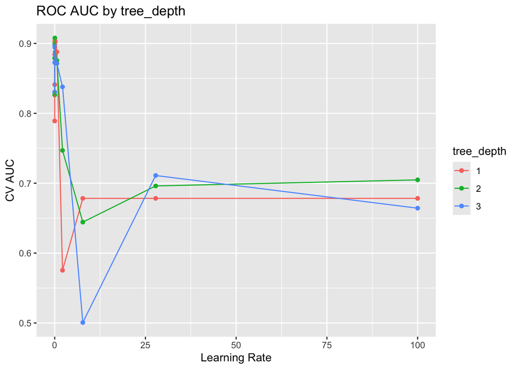

```r
# 2 Heart data
carseats <- Carseats %>%
  mutate(Sales = ifelse(Sales > 8, "high", "low"))

# 3 Initial split into test and non-test sets
set.seed(101)
carseats_split <- initial_split(carseats,
                              prop = 0.8,
                              strata = "Sales")

carseats_other <- training(carseats_split)
carseats_test <- testing(carseats_split)

# 4 recipe (R)
carseats_recipe <-
  recipe(
    Sales ~ .,
    data = carseats_other
  ) %>%
  step_dummy(all_nominal_predictors()) %>%
  step_zv(all_numeric_predictors())

# 5 Model
carseats_mod <-
  boost_tree(
    mode = "classification",
    trees = 1000,
    tree_depth = tune(),
    learn_rate = tune()
  ) %>%
  set_engine("xgboost")

# 6 workflow (R)
carseats_workflow <- workflow() %>%
  add_recipe(carseats_recipe) %>%
  add_model(carseats_mod)

# 7 Tuning grid
carseats_grid <-
  grid_regular(
    tree_depth(range = c(1L, 3L)),
    learn_rate(range = c(-3, 2), trans = log10_trans()),
    levels = c(6,10)
  )

# 8 Cross-validation (CV)
## Set cross-validation partitions
set.seed(101)
folds <- vfold_cv(carseats_other, v = 5)

## Fit cross-validation
carseats_fit <-
  carseats_workflow %>%
  tune_grid(
    resamples = folds,
    grid = carseats_grid,
    metrics = metric_set(roc_auc, accuracy)
  )

## Visualize CV results
carseats_fit %>%
  collect_metrics() %>%
  print(width = Inf) %>%
  filter(.metric == "roc_auc") %>%
  mutate(tree_depth = as.factor(tree_depth)) %>%
  ggplot(aes(x = learn_rate, y = mean, color = tree_depth)) +
  geom_point() +
  geom_line() +
  labs(title = "ROC AUC by tree_depth",
       x = "Learning Rate",
       y = "CV AUC")
```

```r
## Show the top 5 models
carseats_fit %>%
  show_best("roc_auc")
```

```
# A tibble: 5 × 8
  tree_depth learn_rate .metric .estimator  mean     n std_err .config
       <int>      <dbl> <chr>   <chr>      <dbl> <int>   <dbl> <chr>
1          2     0.0464 roc_auc binary     0.908     5 0.00923 Preprocessor1_Mo…
2          1     0.0464 roc_auc binary     0.904     5 0.00654 Preprocessor1_Mo…
3          1     0.167  roc_auc binary     0.903     5 0.00808 Preprocessor1_Mo…
4          2     0.0129 roc_auc binary     0.900     5 0.00667 Preprocessor1_Mo…
5          3     0.0129 roc_auc binary     0.897     5 0.0132  Preprocessor1_Mo…
```

```r
## Let’s select the best model.
best_carseats <-
  carseats_fit %>%
  select_best("roc_auc")
best_carseats
```

```
# A tibble: 1 × 3
  tree_depth learn_rate .config
       <int>      <dbl> <chr>
1          2     0.0464 Preprocessor1_Model11
```

```r
# 9 Finalize our model
## Final workflow
final_carseats <-
  carseats_workflow %>%
  finalize_workflow(
    best_carseats
  )

## Fit the whole training set and then predict
final_fit <-
  final_carseats %>%
  last_fit(carseats_split)

## test metrics
final_fit %>%
  collect_metrics()
```

```
# A tibble: 2 × 4
  .metric  .estimator .estimate .config
  <chr>    <chr>          <dbl> <chr>
1 accuracy binary         0.852 Preprocessor1_Model1
2 roc_auc  binary         0.942 Preprocessor1_Model1
```

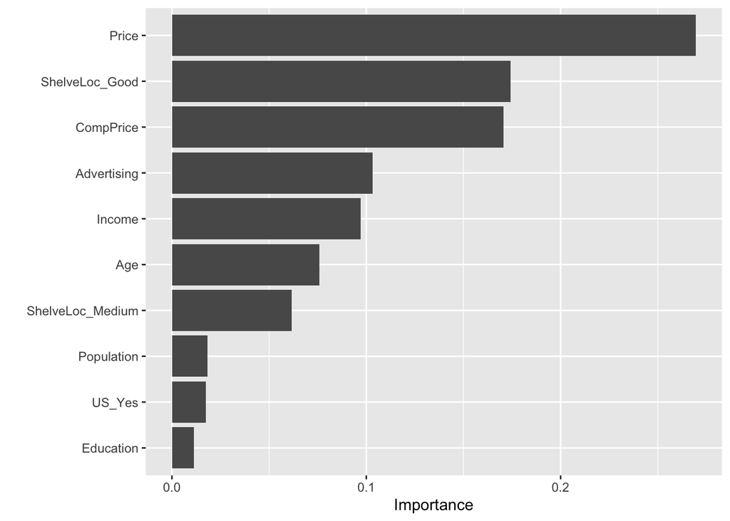

```r
# visualize the model tree
final_tree <- extract_workflow(final_fit)

final_tree %>%
  extract_fit_parsnip() %>%
  vip()
```

The bar chart shows the factors that are most important in predicting sales. The results are consistent with those from a classification tree analysis. The three most important factors are ‘Price’, ‘ShelveLoc_Good’, and ‘CompPrice’. ‘Price’ is the most significant factor, indicating that it is the strongest predictor of high sales. This is understandable since the cost of an item often directly affects a customer’s decision to buy. ‘ShelveLoc_Good’ is the second most influential factor, reflecting whether items are placed in a favorable position within the store and emphasizing the importance of product placement in influencing sales. The ‘CompPrice’ is a crucial factor that can affect a customer’s perception of value when making purchasing decisions.